# Pilot Analysis

Comparison of different policy options to increase COVID-19 vaccination rates.

Jenny Kim, Neel Bhagwat

October 27, 2021

# Abstract

This study focuses on the various policies that the US Federal government can enact to increase COVID-19 vaccination rates and stabilize the spread of COVID-19 with herd immunity. It compares a vaccine mandate enforced with a fine, the policy in question, to various incentives such as tax rebates and sporting tickets. It also takes into account the accessibility of vaccination centers, measured by the proximity of vaccination centers from residencies, as well as combinations of these different policy attributes. The target population for this study are all Americans 18 years and older who have not received a dose of a COVID-19 vaccine. Below are lists of all possible values of each attribute included in the choice questions:

Accessibility (miles from residency):

```
#> [1]  0  1  3 10
```

Incentive (cateogrical):

```
#> [1] "Grocery Store Gift Card" "Internet Rebate"
#> [3] "Sporting Tickets"        "Cash"
```

Mandate Fine (USD, no mandate for values of $0):

```
#> [1]    0   50  100  200  300  500 1000
```

Incentive Value (USD, no incentive for values of $0):

```
#> [1]    0   50  100  200  300  500 1000
```

The results for our study show a high confidence interval for all attributes, plus a positive coefficient for distance to a vaccination center - our respondents had slightly higher preference towards further vaccination centers, an unlikely and unexpected result. The variance and accuracy of our coefficients reemphasizes that we need a larger and more varied sample to get a more accurate and definite estimate. The positive value for distance to a vaccination center also shows a possible interaction effect with another attribute. This informs us that to get accurate readings, we will need to study both interaction and main effects of attributes. To do so, a full factorial design with every possible choice attribute combination will be the most optimal, and we aim to get a sample size as large as possible by reaching out to others in the GW community and across the US.

# Introduction

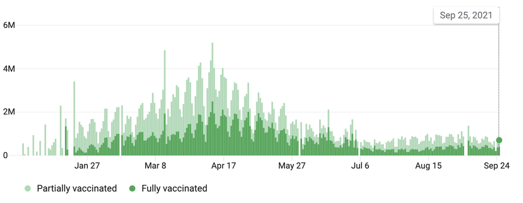

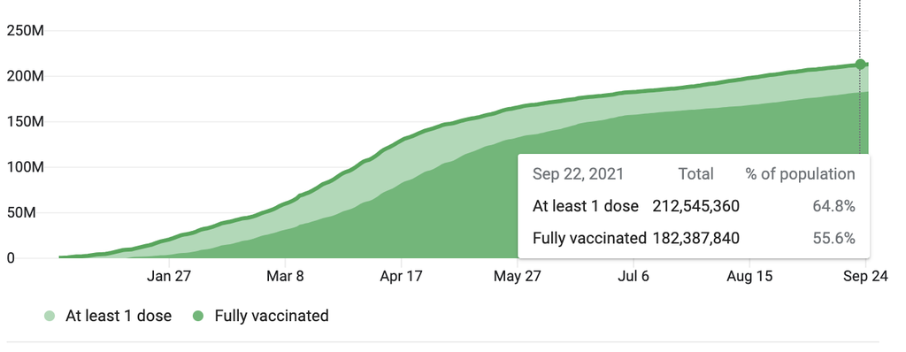

In turn, the Delta variant, a highly-contagious strain of SARS-COV-2, the virus that causes COVID-19, ravaged through unvaccinated populations and caused a surge in cases.

On September 9th, 2021, U.S. President Joe Biden announced vaccine mandates for 100 million Americans, including federal employees and private-sector employees part of firms with over 100 people. This has been met with praise from some experts who claim that forcing Americans to get vaccinated is crucial, criticism from other experts who claim that resistance to vaccine mandates will cause labor shortages and is not effective enough to vaccinate enough of the population [for herd immunity], and hostile resistance, particularly from conservatives, who attack the Constitutional provision of the mandates. View this article to read some of the reactions to Biden’s order.

Vaccine mandates have been touted for months, since the COVID-19 vaccine has become available. But before they were enacted many state and local governments started giving out positive incentives such as money or commodities. All levels of government, from the federal government to local, enacted initiatives to increase access to the vaccine by fighting misinformation and setting up mobile vaccination sites.

Our study analyzes the population and the effectiveness of various policies to increase vaccination rates. Each policy in our study consists of different attributes, which vary across each policy. The goal is to optimize the attributes to get as many people vaccinated as possible. The attributes to be considered are:

### Accessibility

Accessibility refers to the distance which a vaccination clinic would be placed from your home. It varies with 0 (door-door vaccinations) - 10 miles from your residence.

### Incentives

Incentives refers to the type of commodity that would be given out at tax season for being fully vaccinated against COVID-19 by the tax return deadline. It varies by cash tax rebates and cash equivalents (gift cards) redeemable at:

- Grocery stores
- Internet providers
- Professional sporting events

### Incentive Value

Incentive value refers to the value of commodities that would be given out at tax season for being fully vaccinated against COVID-19 by the tax return deadline. It varies by increasing increments from $0 to $1000.

### Penalty

Incentive value refers to the penalty due at tax season for failing to get a being fully vaccinated against COVID-19 by the tax return deadline under a vaccine mandate. It varies by increasing increments from $0 to $1000.

# Survey Design

In order to see what sort of policy would be most appealing to those who are currently unvaccinated, the survey is designed to only collect responses from those who would be able to choose to take the vaccine after seeing the policy options. This consists of adults 18 years or older who have not received any doses of a COVID-19 vaccine. Those under the age of 18 and who have already received a vaccine dose were excluded because they are unable to choose to take the vaccine. This survey is also restricted to United States residents only, as this policy would only be directed towards United States residents.

The survey also collects demographic information relating to age, gender identity, race, income, political affiliation, and geographic location to better inform which policies are most effective for which demographics. Educational material presented to the respondents include information on accessibility, incentives, incentive value, and mandate value, which make up the survey’s attributes.

- Accessibility ranged from 0-10 miles for the distance a vaccination clinic would be placed from a respondent’s home. The accessibility range starts at 0 miles because it is in the most convenient spot possible for a respondent to receive a vaccine, and the range ends at 10 miles because most respondents should have a vaccination location outside of 10 miles from their home.
- Incentive value ranged from $0-$1000 to see if there was a value below $1000 that would sway more people to receive the vaccine. This range stopped at $1000, as anything above that number would most likely be infeasible to implement into a policy.
- Incentives were provided as cash or cash equivalents (gift cards) redeemable at grocery stores, internet providers, and professional sporting events. This range of incentives were chosen as they are items that are necessary and/or popular among the general public.
- Penalties ranged from $0-$1000 to see if there was a value below $1000 that would sway more people to receive the vaccine. This range stopped at $1000, as anything above that number would most likely be infeasible to implement into a policy.

Each respondent receives 10 choice questions that have two options “I will take the vaccine under these conditions” (where the conditions are listed in the option) and “I will not take the vaccine under these conditions”. There is one alternative per choice question (the vaccine conditions) and a no-choice option, where respondents are informed that it means they would not take the vaccine under the conditions listed in the first alternative. An example figure of a random conjoint question can be seen below.

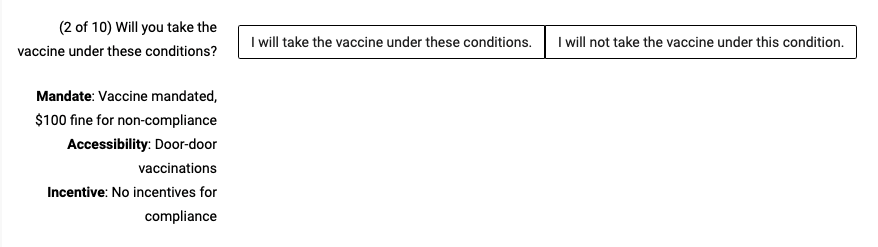

# Pilot Data Analysis

### Data Cleaning

When we first opened the responses from the three separate components, we noticed a lot of null values to numerous attributes, including session ids that seemed to be from unsuccessful attempts to view our survey, or from bots on the internet. To remove these values gracefully, we had to join these three components together by the session id, a unique identifier for each participant associated with the survey. To do so, we took out duplicate columns and removed null values for session. We also computed the time took to complete each survey component in unique columns. Then, we filtered out respondents that did not answer the choice questions and did not meet eligibility criteria. There were about 20-30 total respondents, but the actual number is not known because some responses on each part were due to unsuccessful attempts to take the survey (i.e. partial responses, bots, poor network connection, etc.).

## Sample Description

The final pilot survey sample after cleaning consists of 7 respondents who answered all 10 choice questions and met the eligibility criteria. The choice data sheet contains of 20 rows per respondent, denoting 2 alternatives per question (will you take the vaccine under this condition or not?) and 10 questions each.

```
#> # A tibble: 140 × 31
#>    session    time_sec_p1 consentAge consentVaccine consentUndersta… time_sec_p2
#>    <chr>            <dbl>      <dbl>          <dbl>            <dbl>       <dbl>
#>  1 gentleVul…          10          1              1                1         180
#>  2 gentleVul…          10          1              1                1         180
#>  3 gentleVul…          10          1              1                1         180
#>  4 gentleVul…          10          1              1                1         180
#>  5 gentleVul…          10          1              1                1         180
#>  6 gentleVul…          10          1              1                1         180
#>  7 gentleVul…          10          1              1                1         180
#>  8 gentleVul…          10          1              1                1         180
#>  9 gentleVul…          10          1              1                1         180
#> 10 gentleVul…          10          1              1                1         180
#> # … with 130 more rows, and 25 more variables: respID <dbl>, time_sec_p3 <dbl>,
#> #   yearOfBirth <dbl>, gender <chr>, genderOther <lgl>, race <dbl>,
#> #   raceOther <lgl>, income <chr>, politics <dbl>, region <dbl>, time17 <dttm>,
#> #   feedback <chr>, completionCode <dbl>, qID <dbl>, choice <dbl>, altID <dbl>,
#> #   obsID <dbl>, value <dbl>, penalty <dbl>, accessibility <dbl>,
#> #   incentive_cash <dbl>, incentive_grocery_store <dbl>,
#> #   incentive_internet <dbl>, incentive_sport_tickets <dbl>, …
```

### Demographic Analysis

To analyze our sample by each demographic factor, we first filtered out any respondent who did not answer the particular demographic question. We then grouped respondents by demographic and divided the number of responses to each demographic by 20 (since each respondent appears 20 times on the survey) to get the number of respondents in each demographic attribute level.

We were first interested in the politics of our respondents. We found that most of our sample was liberal, with a couple independents and leaning conservatives. This deviates from our ideal sample - we will need responses across a wide political spectrum and we will need more samples in each category - a liberal sample may skew responses towards agreeing to take the vaccine under smaller conditions.

```
#> # A tibble: 4 × 3
#>   politics num_respondents political_label
#>      <dbl>           <dbl> <chr>
#> 1        3               1 Leaning conservative
#> 2        6               3 Liberal
#> 3        7               2 Strongly liberal
#> 4        8               1 Independent
```

We were also interested in the income brackets of our respondents. We found that most of our sample makes under $50,000 per year, which can give us insights about vaccine policies for poorer families, but we will need more responses from a higher income bracket to validate the effect of income on vaccine hesitancy.

```
#> # A tibble: 5 × 2
#>   income       num_respondents
#>   <chr>                  <dbl>
#> 1 inc_100to150               1
#> 2 inc_10to15                 1
#> 3 inc_150to200               1
#> 4 inc_35to50                 2
#> 5 under10                    2
```

We then looked at the regions of residencies of our respondents. We found that our sample is overwhelmingly from the East Coast, with a few responses from the West Coast and the Rocky Mountains. We will need more responses from the Midwest and New England. We also realize from the low variation in region that splitting up our sample by state will give us a more granular analysis on the effect of location on vaccine sentiment.

```
#> # A tibble: 4 × 3
#>   region num_respondents region_label
#>    <dbl>           <dbl> <chr>
#> 1      2               2 Middle Atlantic
#> 2      3               3 South Atlantic
#> 3      8               1 Mountain
#> 4      9               1 Pacific
```

We also looked at the genders of our respondents. The sample is more balanced with respect to gender with other demographic attributes like we want, but the sample can use more male responses, as well as responses from those in the trans/non-binary community.

```
#> # A tibble: 3 × 2
#>   gender    num_respondents
#>   <chr>               <dbl>
#> 1 female                  4
#> 2 male                    2
#> 3 transMale               1
```

We also looked at the ages of our sample. We noticed that all our respondents are young adults, and we need more samples from the elderly and middle-aged adults to get a better prediction for age as their is more likely to be variation between generations as opposed to ages within a generation.

```
#> # A tibble: 5 × 2
#>     age num_respondents
#>   <dbl>           <dbl>
#> 1    21               1
#> 2    22               2
#> 3    23               1
#> 4    25               1
#> 5    29               2
```

### Modeling

The first three beta values represent continuous attributes, and for every change in value, accessibility, and penalty, the utility for policy j will increase by the beta value for that attribute * the level of the attribute. The last four beta values are for categorical attributes that can either be 0 or 1, with 0 denoting the attribute is not present and 1 denoting the presence of an attribute. If present, the utility for policy j will increase by the beta value for that attribute.

Using the model and the choice data, we then ran the logitr model using preference space to estimate the beta coefficients. Running a summary of the results returned to us the estimated coefficients and the standard error. It also returned to us the log likelihood that the coefficients are correct and can be used to accurately estimate utility.

```
#> =================================================
#> Call:
#> logitr(data = data, outcome = "choice", obsID = "obs_id", pars = c("value",
#>     "penalty", "accessibility", "incentive_cash", "incentive_grocery_store",
#>     "incentive_internet", "incentive_sport_tickets"))
#>
#> Frequencies of alternatives:
#>       1       2
#> 0.88571 0.11429
#>
#> Exit Status: 3, Optimization stopped because ftol_rel or ftol_abs was reached.
#>
#> Model Type:    Multinomial Logit
#> Model Space:          Preference
#> Model Run:                1 of 1
#> Iterations:                   16
#> Elapsed Time:        0h:0m:0.01s
#> Algorithm:        NLOPT_LD_LBFGS
#> Weights Used?:             FALSE
#> Robust?                    FALSE
#>
#> Model Coefficients:
#>                            Estimate  Std. Error z-value Pr(>|z|)
#> value                    0.00203560  0.00170004  1.1974  0.23116
#> penalty                 -0.00069686  0.00135730 -0.5134  0.60766
#> accessibility            0.12167562  0.12799336  0.9506  0.34179
#> incentive_cash           2.35729371  1.07136929  2.2003  0.02779 *
#> incentive_grocery_store  1.44627513  1.20589568  1.1993  0.23040
#> incentive_internet       1.19017218  0.81118015  1.4672  0.14232
#> incentive_sport_tickets  0.82842000  0.90984981  0.9105  0.36256
#> ---
#> Signif. codes:  0 '***' 0.001 '**' 0.01 '*' 0.05 '.' 0.1 ' ' 1
#>
#> Log-Likelihood:         -22.8546670
#> Null Log-Likelihood:    -48.5203026
#> AIC:                     59.7093340
#> BIC:                     75.4488000
#> McFadden R2:              0.5289669
#> Adj McFadden R2:          0.3846974
#> Number of Observations:  70.0000000
```

We then validated the accuracy of the model by checking whether the model is at a maximum, because we need to maximize log likelihood. We checked the results against the first-order and second-order derivatives of the model.

```
#>                                  [,1]
#> value                    5.459308e-01
#> penalty                  6.216688e-01
#> accessibility           -7.010661e-03
#> incentive_cash           7.865343e-05
#> incentive_grocery_store  3.175329e-04
#> incentive_internet       1.330896e-03
#> incentive_sport_tickets  7.284446e-04
```

```
#> [1] -8.674548e+05 -5.437048e+05 -7.981055e+01 -2.428765e+00 -1.311316e+00
#> [6] -9.102517e-01 -5.498163e-01
```

The first derivates for each attribute were close but not equal to 0. The second order derivatives in the hessian are all negative, denoting that the model has a maximum and is curved down. Since most first order derivatives are positive and all second order derivatives are negative, we can infer that the optimal values for betas are higher than estimated by the model, and for attributes with a negative first derivative, the actual values for betas are lower than estimated. But we concluded that with more data it would be easier to find measurable optimal values for beta.

We then extracted the coefficients and standard errors to reference when plotting each attribute.

```
#>                   value                 penalty           accessibility
#>            0.0020356017           -0.0006968554            0.1216756243
#>          incentive_cash incentive_grocery_store      incentive_internet
#>            2.3572937051            1.4462751294            1.1901721788
#> incentive_sport_tickets
#>            0.8284200014
```

```
#>                   value                 penalty           accessibility
#>             0.001700039             0.001357301             0.127993359
#>          incentive_cash incentive_grocery_store      incentive_internet
#>             1.071369286             1.205895681             0.811180154
#> incentive_sport_tickets
#>             0.909849814
```

After getting the estimates and errors for beta, we proceeded to plot the utility for each attribute with each beta estimate. For plotting each attribute:

- We created a new data frame containing estimates plus upper and lower bound estimates calculated by the estimated coefficient, the standard error, and the attribute level. The upper and lower bounds are the 95% confidence interval for the estimate, or beta +- 2* std_err.
- We plotted the attribute and the upper and lower bounds. For categorical attributes, we used box and whiskers plots to show the confidence interval. For continuous attributes, we shaded in the confidence interval.

#### Plot for value of incentive

We plotted the value of the incentive to utility, and there was high variation, particularly for higher values of beta.

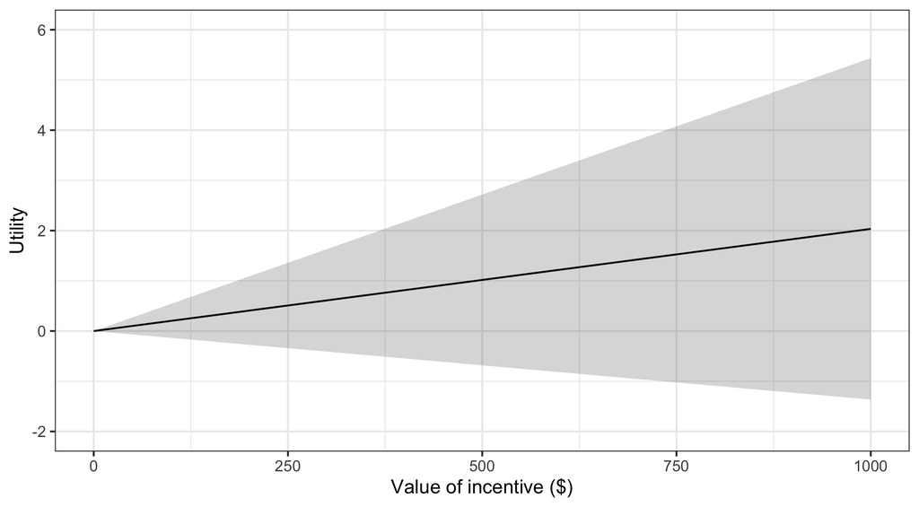

The plot for the value of incentive shows a generally positive utility with a very large confidence interval. This positive utility is expected because a larger incentive should hypothetically increase willingness to receive a COVID-19 vaccine. This significant variance needs to be offset by more samples. We hope to receive more respondents in our actual survey in order to minimize the variance.

#### Plot for accessibility to vaccination center

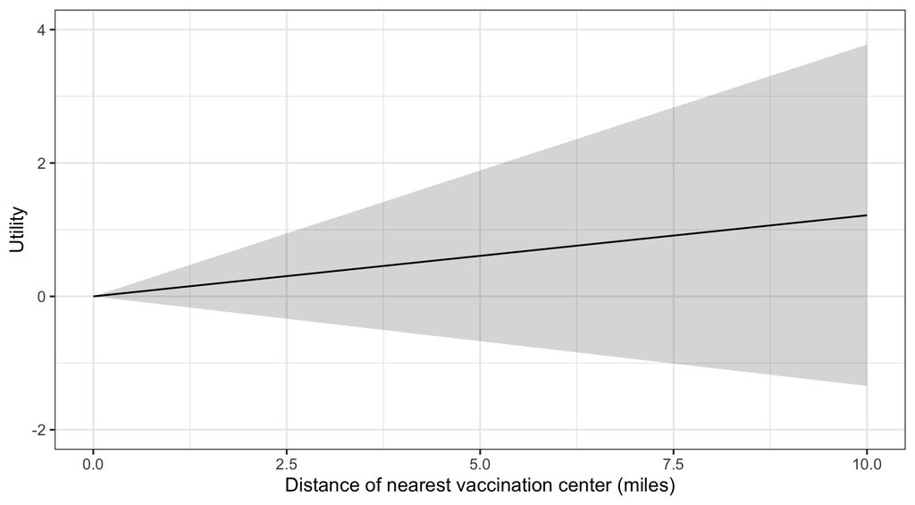

The plot for accessibility to a vaccination center shows a generally positive utility with a large confidence interval. The positive coefficient for accessibility shows that there may be a bias occurring in the sample. This is unexpected, as the distance to a vaccination center increases, the difficulty for a respondent to to receive a COVID vaccination increases which should likely result in a negative utility. This could be due to our small sample size and/or an interaction effect. This variable and coefficient will need to have a larger sample size in order to be a full factorial design, which will allow us to study both interaction and main effects of each attribute. We hope to receive more respondents in our actual survey in order to minimize the variance.

#### Plot for non-compliance penalty

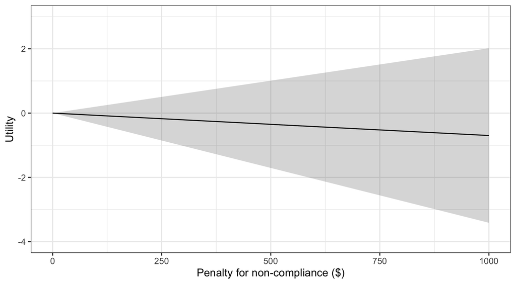

The plot for a non-compliance penalty shows a slightly negative utility with a moderately big confidence interval. This negative utility is interesting because a larger tax penalty should hypothetically increase the willingness to receive a COVID-19 vaccine, but an extremely large fine may also discourage trust in the healthcare system and furthermore, vaccinations. Distrust is expected from more conservative demographics, as conservatives are more likely to distrust vaccine policies and information. This further emphasizes a need for a larger sample and full factorial design in order to confirm this hypothesis and find correlation between the utility, specific demographics, and interaction effects. This variance needs to be offset by more samples. We hope to receive more respondents in our actual survey in order to minimize the variance.

#### Plot for cash incentives

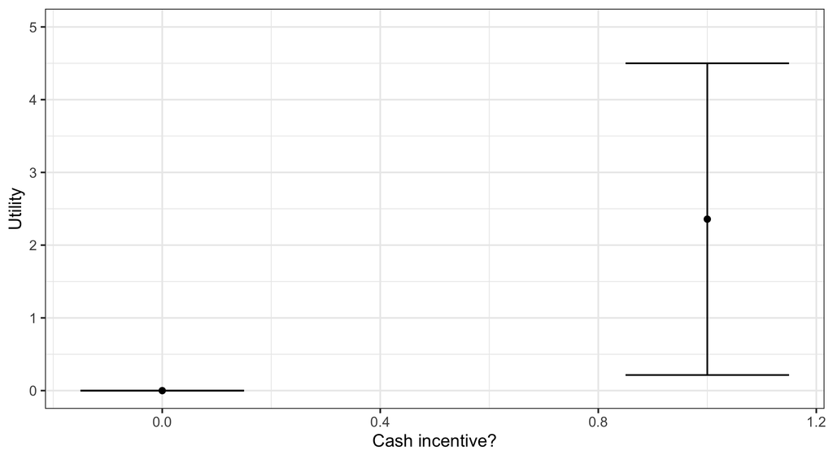

The plot for cash incentives shows a generally positive utility with a very large confidence interval. This positive utility is expected because a larger incentive should hypothetically increase willingness to receive a COVID-19 vaccine. This significant variance needs to be offset by more samples. We hope to receive more respondents in our actual survey in order to minimize the variance.

#### Plot for grocery store credit incentives

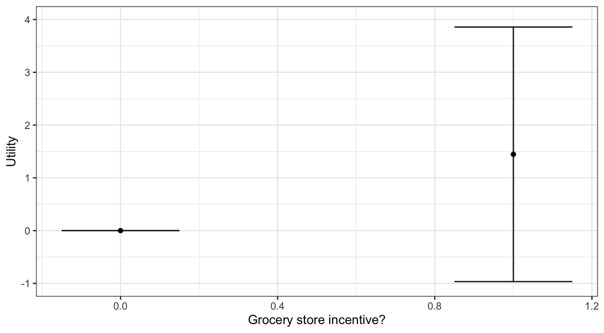

The plot for a grocery store credit incentive shows a generally positive utility with a large confidence interval. This positive utility is expected because a larger grocery store credit should hypothetically increase willingness to receive a COVID-19 vaccine. This significant variance needs to be offset by more samples. We hope to receive more respondents in our actual survey in order to minimize the variance.

#### Plot for internet bill credit incentives

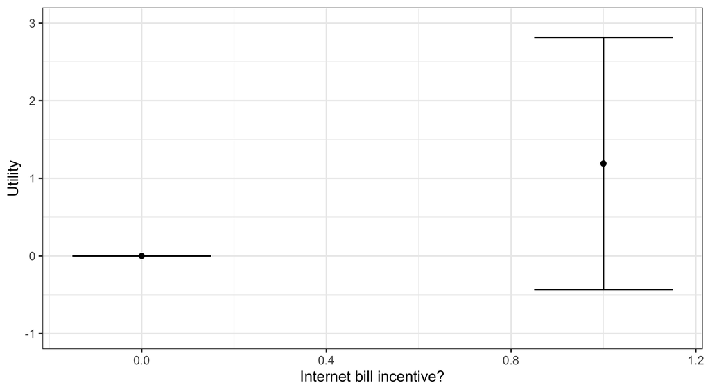

The plot for an internet bill credit incentive shows a generally positive utility with a large confidence interval. This positive utility is expected because a larger internet bill credit should hypothetically increase willingness to receive a COVID-19 vaccine. This significant variance needs to be offset by more samples. We hope to receive more respondents in our actual survey in order to minimize the variance.

#### Plot for sporting event tickets incentives

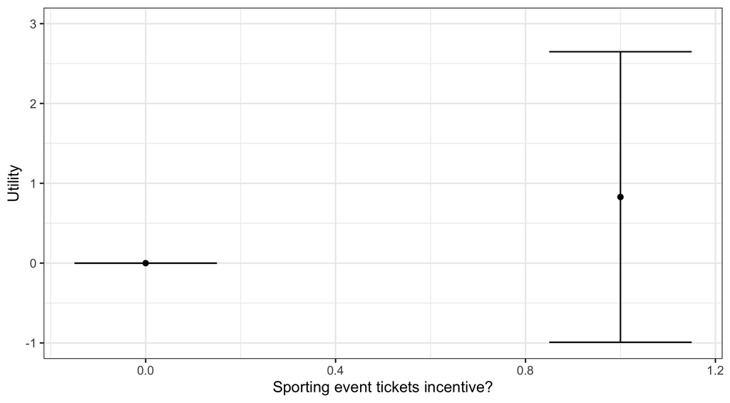

The plot for a sporting event ticket incentive shows a slightly positive utility with a moderately large confidence interval. This positive utility is expected because a larger sporting event credit should hypothetically increase willingness to receive a COVID-19 vaccine. This attribute also had the smallest coefficient, which is consistent with our expectations that sporting tickets are less of a necessity and more niche than our other attributes. The variance needs to be offset by more samples. We hope to receive more respondents in our actual survey in order to minimize the variance.

# Power Analysis

```
#>   nTrials     d balanced
#> 1     100 0.926    FALSE
```

```
#> $d_eff
#> [1] 0.699
#>
#> $balanced
#> [1] FALSE
```

```
#>    sampleSize                   coef           est           se
#> 1        1000 incentivegrocery_store -3.966584e-02 1.289958e-01
#> 2        1000      incentiveinternet  1.440039e-02 1.269721e-01
#> 3        1000 incentivesport_tickets -9.976884e-02 1.286745e-01
#> 4        1000                  value -1.243810e-04 1.379785e-04
#> 5        1000                penalty -2.663108e-04 1.545812e-04
#> 6        1000          accessibility  1.431838e-02 1.143444e-02
#> 7        2000 incentivegrocery_store -1.361924e-01 8.941861e-02
#> 8        2000      incentiveinternet  3.639045e-02 8.910005e-02
#> 9        2000 incentivesport_tickets -6.904769e-02 9.043377e-02
#> 10       2000                  value -1.510229e-04 9.929900e-05
#> 11       2000                penalty -8.692240e-05 1.082738e-04
#> 12       2000          accessibility -7.496963e-04 8.159141e-03
#> 13       3000 incentivegrocery_store -6.017581e-02 7.324196e-02
#> 14       3000      incentiveinternet  1.638169e-02 7.365989e-02
```

[output cut: 46 more lines]

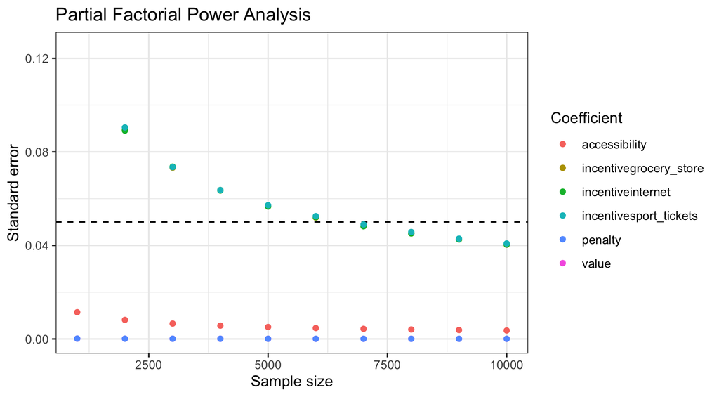

# Changes to Final Survey

- We removed unnecessary images that may confuse respondents due to classmate feedback.
- We added a sentence that says I will take the vaccine under these conditions to make it more clear that the respondent is either choosing to take the vaccine under the conditions listed or not take it.
- We also separated the buttons between the choices to be more visually clear.
- We adjusted our attention checks to be less confusing due to classmate feedback.
- We removed our regional map question and decided to ask instead what state respondents are from to understand their location better. Classmates had informed us that the regional map was confusing and unclear.
- We still hope to achieve the necessary sample size for our survey of at least around 300 people. We will do this by reaching out to the following people/groups to gain responses:
  - Dr. Lorien Abroms, a Public Health professor, runs the GW Health Communications Corps, an organization combating health misinformation. Dr. Abroms would particularly be integral with identifying groups of people that succumb to microaggressions and have lower vaccination rates*. Dr. Abroms can also help us gain more samples from groups that succumb to misinformation about the vaccine, as a report from HHS in August 2021 estimates that 44% of unvaccinated fall into the “unvaccinated but willing” category. This would help to reduce the bias in the sample towards a positive or negative policy, identifying a group of people that is willing to take the vaccine without any incentive or consequence wagered will help us identify the most efficient policy and whether incentives or fines are absolutely necessary.
  - Dr. Dennis Schell, a Psychology professor, teaches general and abnormal psychology. He also works with people with adverse behavior issues, and will be able to help garner surveys from people with behavioral health issues on why they won’t take the vaccine. With these people in our sample, we will be able to identify whether they can comply with a vaccine mandate.
  - Dr. Patrick McHugh is a Professor of Management whose research is focused on the psychology behind organizational structure and operations. He will be able to identify organizations that do not require vaccinations for its members, and give insight as to the reception towards vaccine mandates. He can also help us identify organizations that incentivize decisions, which we can send the survey to.
  - No Lost Generation GW is an organization that helps refugees adjust to living in the United States, particularly in the DC area. We can talk to the organization about getting refugees vaccinated by translating the survey into various languages and allowing refugees and immigrants to take them.
  - Dr. Irene Foster is a Professor of Economics who can give insight on different unvaccinated populations in the US. She may be able to give contacts of people who work with the above groups to whom we can share the survey with.

# Appendix

Survey Link: https://pilotanalysis.formr.org/

## Introduction

Welcome to our survey!

Thank you for your interest in our survey! The purpose of this survey is to to inform the design decisions of a COVID vaccine policy. This survey is being conducted by students at The George Washington University for a Marketing Analytics course. You must be a resident of the United States above the age of 18 who has not received a dose of a COVID-19 vaccine to partake in this survey.

This survey involves questions that ask whether a certain condition would result in you receiving the COVID-19 vaccine. These conditions can be seen as positive, negative, or neutral. These conditions will not actually occur and you will not need to actually take a COVID-19 vaccine based on your answers in this survey. All responses will be used purely for educational purposes. At the end of the survey we will be collecting demographic information (such as income and age) that will also be used purely for educational purposes.

If you have any questions about this survey, then please contact marketingvaccinepolicy@gmail.com.

## Consent

Your participation in this survey is voluntary. You may choose not to participate. If you decide to participate in this survey, you may withdraw at any time with no penalty. All responses will be used solely for educational purposes. Your responses will be confidential and we will not collect or share any identifying data such as your name or address.

The whole survey will take approximately 10 to 15 minutes to complete. If you would like to participate, please answer the following questions:

## Eligibility Questions

I am age 18 or older.

- Yes
- No

I have not received any doses of a COVID-19 vaccine.

- Yes
- No

I have read and understand the above information.

- Yes
- No

## Education

Great work! Now that you’ve shared a bit about yourself, we’d like you to consider policies designed to encourage COVID-19 vaccinations. Let’s learn about policy attributes.

### Incentives

Incentives refers to the type of commodity that would be given out at tax season for being fully vaccinated against COVID-19 by the tax return deadline. It varies by cash and cash equivalents (gift cards) redeemable at:

- Grocery stores
- Internet providers
- Professional sporting events

### Incentive Value

Incentive value refers to the value of commodities that would be given out at tax season for being fully vaccinated against COVID-19 by the tax return deadline. It varies by increasing increments from $0 to $1000.

### Mandate Value

Mandate value refers to the penalty due at tax season for failing to get a being fully vaccinated against COVID-19 by the tax return deadline under a vaccine mandate. It varies by increasing increments from $0 to $1000.

## Practice Question

We’ll now begin with policy options. On the next few pages we will show you different combinations of policy options regarding COVID-19 vaccinations.

For example, if these were the only options available, would you choose option 1 (a $100 fine if you do not take the vaccine, a vaccination clinic 5 miles from your house, and a professional sporting event ticket) and take the vaccine or choose option 2 and not take the vaccine.

**Option 1**

**Mandate**: $100 **Accessibility**: 5 miles **Incentive**: Professional sporting event

I will take the vaccine under these conditions.

**Option 2**

I will not take the vaccine under these conditions.

## Attention Check

This is an attention check. Please choose Option 1 and continue.

**Option 1** **Option 2**

## Conjoint Questions

Great work!

We will now show you 10 sets of choice questions starting on the next page. (Image shown below is an example of a choice question)

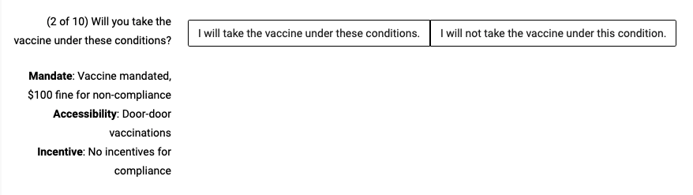

## Respondent Information

Nice job!

We’re almost done! We’d just like to ask just a few more questions about you which we will only use for analyzing our survey data.

1. In what year were you born?
- All years from 1920-2003 are listed
2. What is your current gender identity?
- Male
- Female
- Trans male/trans man
- Trans female/trans woman
- Genderqueer/gender non-conforming
- Prefer not to say

Different identity (please state):

3. I identify my race as (select all that apply):
- Native American or Alaskan Native (e.g., Navajo Nation, Blackfeet Tribe, Mayan, Aztec, Native Village of Barrow Inupiat Traditional Government, Nome Eskimo Community, etc.)
- Asian (e.g., Chinese, Filipino, Indian, Vietnamese, Korean, Japanese, Malaysian, etc.) African (e.g., African American, Jamaican, Haitian, Nigerian, Ethiopian, Somalian, etc.)
- Hispanic or Latino (e.g., Mexican or Mexican American, Puerto Rican, Cuban, Salvadoran, Dominican, Colombian, etc.)
- Middle Eastern or North African (e.g., Lebanese, Iranian, Egyptian, Syrian, Moroccan, Algerian, etc.)
- Native Hawaiian or Pacific Islander (e.g., Native Hawaiian, Samoan, Chamorro, Tongan, Fijian, Marshallese, etc.)
- Caucasian (e.g., German, Irish, English, Italian, Polish, French, etc.) Prefer not to say

Different identity (please state):

4. What is your annual household income (from all sources) before taxes and other deductions from pay?
- Less than $10,000
- $10,000 - $14,999
- $15,000 - $24,999
- $25,000 - $34,999
- $35,000 - $49,999
- $50,000 - $74,999
- $75,000 - $99,999
- $100,000 - $149,999
- $150,000 - $199,999
- $200,000 or more
- Prefer not to say
5. What is your political orientation?
- Strongly conservative
- Conservative
- Leaning conservative
- Moderate
- Leaning liberal
- Liberal
- Strongly liberal
- Independent
- Prefer not to say
6. What state do you live in?
- All 50 states and the District of Columbia are listed

## Feedback

Please let us know if you have any other thoughts or feedback on this survey.

Your feedback will help us make future improvements :)